# Final_Exam

# Here I’m attempting to construct a clustering model in order to determine whether we can separate people into distinct catergories.Using k means clustering for this.i opted to look at the log and norm transformations and use the elbow technique to compute the minimum errors and decide how many clusters to divide the data into because the summary data comprises variables at different scales.

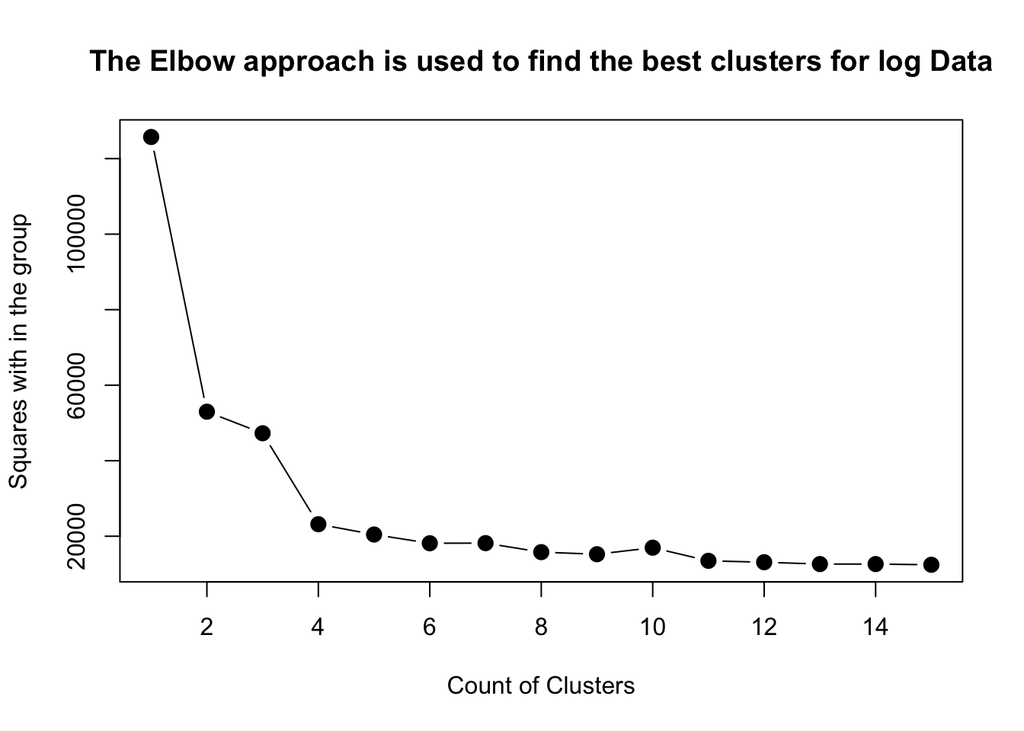

```r
set.seed(00909)

normalize <-function(x) {
  return((x-min(x))/(max(x) - min(x)))

}
ft_data_log = log(f_data[,-1]+2)

ft_data_norm = as.data.frame(lapply(f_data[,-1],normalize))


score_wss_log<-(nrow(ft_data_log)-1)*sum(apply(ft_data_log,2,var))

for (i in 2:15)  score_wss_log[i] <-sum(kmeans(ft_data_log,centers = i)$withinss)



plot(1:15,score_wss_log[1:15],type = "b",xlab = "Count of Clusters",ylab="Squares with in the group",main = "The Elbow approach is used to find the best clusters for log Data",pch=20,cex=2)
```

```r
score_wss_normal<-(nrow(ft_data_norm)-1)*sum(apply(ft_data_norm,2,var))

for (i in 2:15)
  score_wss_normal[i] <-sum(kmeans(ft_data_norm,
                                   centers = i)$withinss)
```

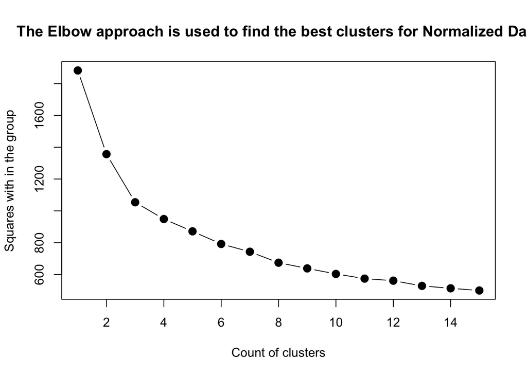

```r
plot(1:15,score_wss_normal[1:15],type = "b",xlab = "Count of clusters",ylab = "Squares with in the group",main = "The Elbow approach is used to find the best clusters for Normalized Data",pch=20,cex=2)
```

# The normalized data makes more sense to proceed with, as seen by the charts above.

# Denormalize the data and look at the centers means of each variable in the Three clusters

```r
minvec <-sapply(f_data[,-1],min)
maxvec<-sapply(f_data[,-1],max)
denormalize<-function(x,minval,maxval)
  return(x*(maxval-minval))



set.seed(009)
kmeans_3_cl_normal = kmeans(ft_data_norm,3,nstart = 100)

kmeans_3_cl_actual = NULL
t1=NULL

for (i in 1:10)
  {  t1 = (kmeans_3_cl_normal$centers[,i] * (maxvec[i]-minvec[i])) + minvec[i]
     kmeans_3_cl_actual = cbind(kmeans_3_cl_actual,t1)

}

colnames(kmeans_3_cl_actual) = colnames(f_data[-1])
print("Below is the mean value of all variables in each cluster")
```

```
## [1] "Below is the mean value of all variables in each cluster"
```

```r
kmeans_3_cl_actual
```

```
##   All_of_the_orders Last_7_Days_orders In_the_Last_4_weeks_orders
## 1          2.797698          0.3056266                   1.204859
## 2          2.513654          0.0000000                   0.000000
## 3         17.050763          0.7103517                   3.042468
##   Distance_Fromthe_Resturant_on_Average Typically_DeliveryTime
## 1                              2.355601               36.06829
## 2                              2.378023               38.51625
## 3                              2.338056               36.37691
##   countdown_to_the_Last_Order Days_since_Initial_Order   Av_All Av_Last_7_Days
## 1                    56.89335                 74.20307 377.2760       73.37749
## 2                   142.50163                159.91125 360.9083        0.00000
## 3                    47.51924                173.80425 336.6768      124.55076
##   Av_Last_4_Weeks
## 1        200.5054
## 2          0.0000
## 3        255.7472
```

```r
print("The following table shows the number of customers in each cluster")
```

```
## [1] "The following table shows the number of customers in each cluster"
```

```r
kmeans_3_cl_normal$size
```

```
## [1] 3910 3076 3014
```

```r
#kmeans_3_cl_normal$centers
#fviz_cluster(kmeans_3_cl_normal,data = ft_data_norm)
```

# we can observe from the mean values of each variable in each of the three clusters that transaction frequency and AV are the most variable, whereas typical delivery time and distance on average are not.

# Classification of customers:

1.Over the last 7 days and 4 weeks customers are active but with Low frequency and Low Av. 2.Over the last 7 days and 4 weeks ,customers are active with high frequency and High Av. 3.Customers are not in active since last 7 days and over 4 weeks

# Building the cluster for active customers by removing the users who did not interacted in last 4 weeks

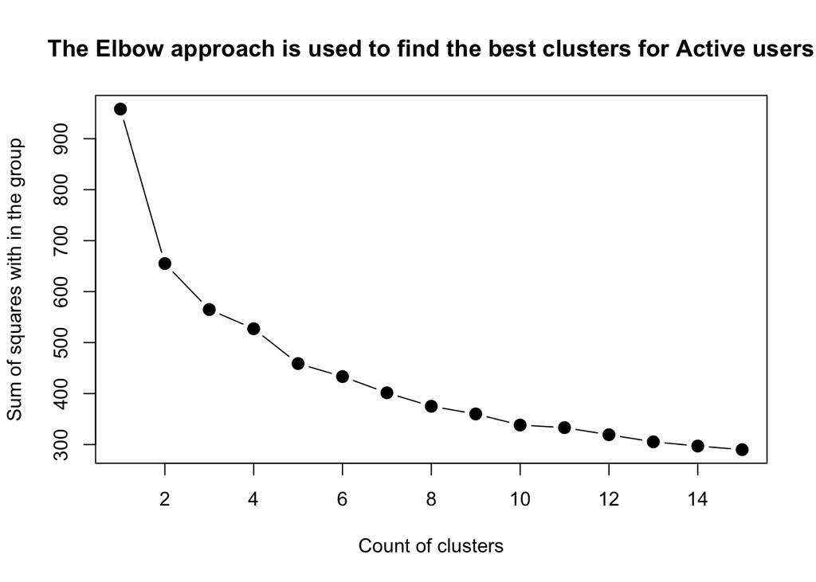

```r
ft_order_data = f_data[f_data$In_the_Last_4_weeks_orders !=0,]

normalize <-function(x) {
  return((x-min(x))/ (max(x)-min(x)))
}

 ft_order_data_norm=as.data.frame(lapply(ft_order_data[,-1],normalize))

 score_wss_order_normal<-(nrow(ft_order_data_norm)-1)*sum(apply(ft_order_data_norm,2,var))

 for (i in 2:15) score_wss_order_normal[i] <- sum(kmeans(ft_order_data_norm,centers = i)$withinss)




 plot(1:15,score_wss_order_normal[1:15],type = "b", xlab = "Count of clusters", ylab = "Sum of squares with in the group", main = "The Elbow approach is used to find the best clusters for Active users",pch=20,cex=2)
```